# Zigzag expanded navigation plots in R: The R package zenplots

### 2.1 Layout

To investigate the layout options of zenplots a bit more, we need a larger data set. To this end we simply double the olive data here (obviously only for illustration purposes):

```r
olive2 <- cbind(olive, olive) # just for this illustration
```

Reproducing the plots of Figure 2:

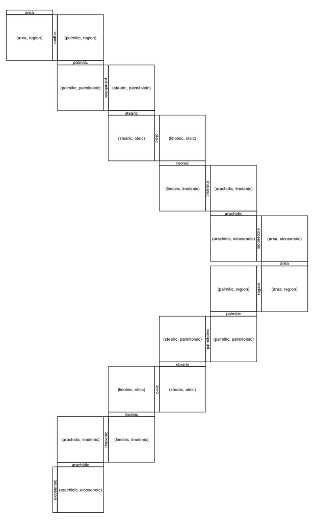

```r
zenplot(olive2, n2dcols = 6, plot1d = "layout", plot2d = "layout",
        method = "single.zigzag")
```

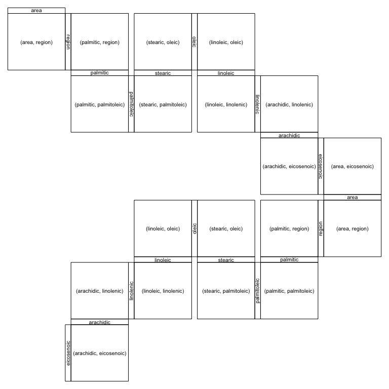

```r
zenplot(olive2, n2dcols = 6, plot1d = "layout", plot2d = "layout",
        method = "double.zigzag")
```

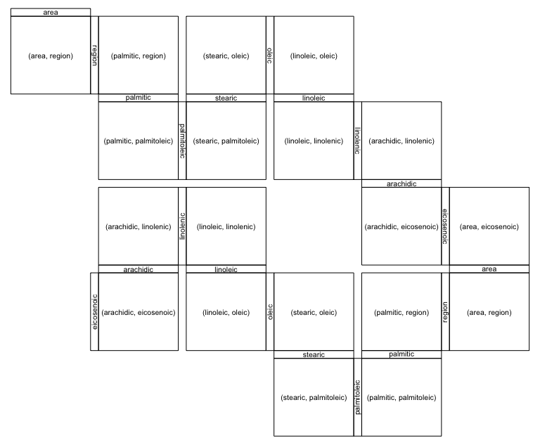

```r
zenplot(olive2, n2dcols = 6, plot1d = "layout", plot2d = "layout",
        method = "tidy")
```

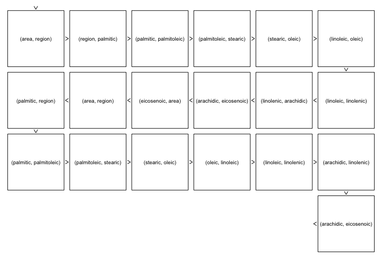

```r
zenplot(olive2, n2dcols = 6, plot1d = "arrow", plot2d = "layout",
        method = "rectangular")
```

Reproducing the plots of Figure 3:

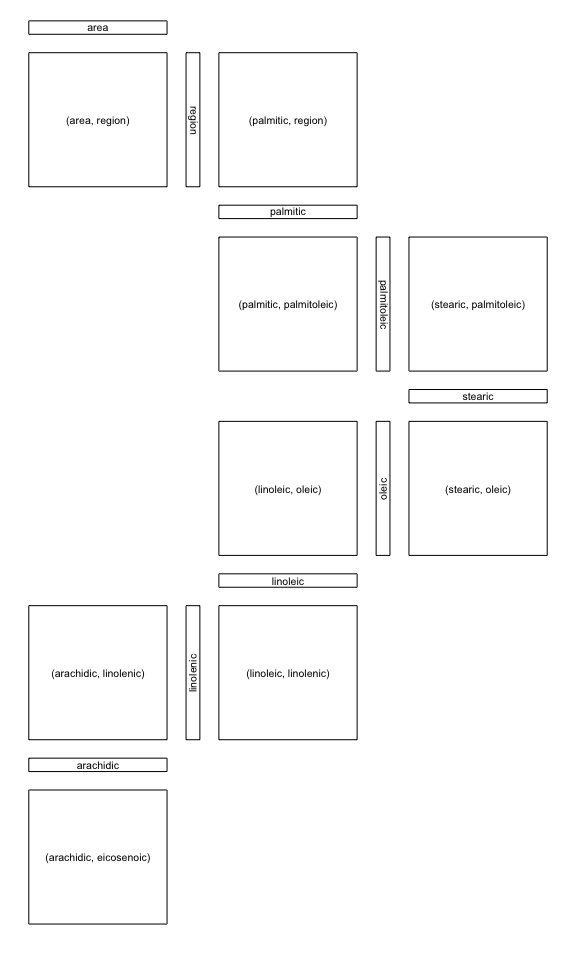

```r
zenplot(olive, plot1d = "layout", plot2d = "layout", method = "double.zigzag",
        last1d = FALSE, ispace = 0.1)
```

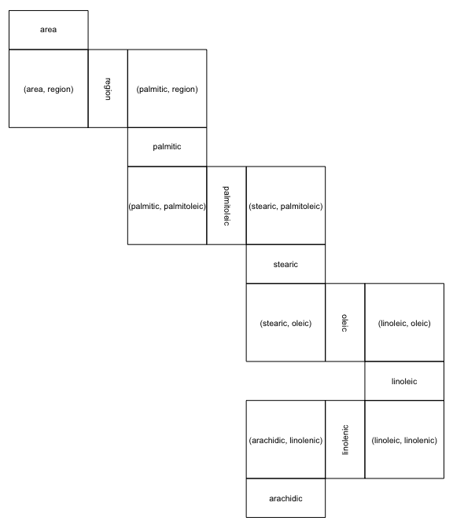

```r
zenplot(olive, plot1d = "layout", plot2d = "layout", n2dcol = 4, n2dplots = 8,
        width1d = 2, width2d = 4)
```

## 3 Zenpaths

A very basic path (standing for the sequence of pairs (1,2), (2,3), (3,4), (4,5)):

```r
(path <- 1:5)
```

```
## [1] 1 2 3 4 5
```

A zenpath through all pairs of variables (Eulerian):

```r
(path <- zenpath(5))
```

```
##  [1] 5 1 2 3 1 4 2 5 3 4 5
```

If `dataMat` is a five-column matrix, the zenplot of all pairs would then be constructed as follows:

```r
zenplot(x = dataMat[,path])
```

The `str()`ucture of `zenpath()` (again formatted for nicer output):

```r
str(zenpath)
```

```r
function (x, pairs = NULL,
          method = c("front.loaded", "back.loaded", "balanced",
                     "eulerian.cross", "greedy.weighted", "strictly.weighted"),
          decreasing = TRUE)
```

Here are some methods for five variables:

```r
zenpath(5, method = "front.loaded")
```

```
##  [1] 5 1 2 3 1 4 2 5 3 4 5
```

```r
zenpath(5, method = "back.loaded")
```

```
##  [1] 1 2 3 1 4 2 5 3 4 5 1
```

```r
zenpath(5, method = "balanced")
```

```
##  [1] 1 2 3 5 4 1 3 4 2 5 1
```

The following method considers two groups: One of size three, the other of size five. The sequence of pairs is constructed such that the first variable comes from the first group, the second from the second.

```r
zenpath(c(3,5), method = "eulerian.cross")
```

```
##  [1] 1 4 2 5 1 6 2 7 1 8 3 4 3 6 7 3 5 8 2
```

Reproducing Figure 4:

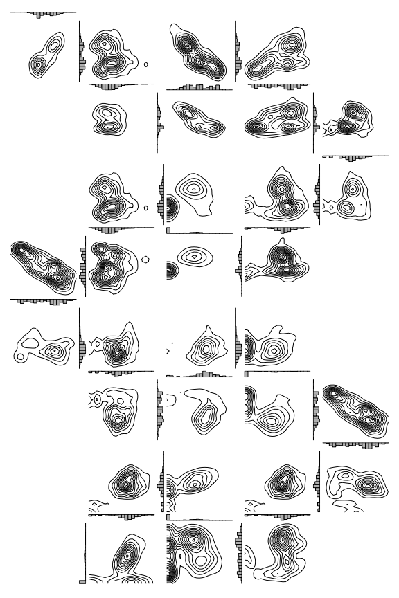

```r
oliveAcids <- olive[, !names(olive) %in% c("area", "region")] # acids only
zpath <- zenpath(ncol(oliveAcids)) # all pairs
zenplot(oliveAcids[, zpath], plot1d = "hist", plot2d = "density")
```

## 4 Build your own zenplots

### 4.3 Custom layout and plots – a spiral of ggplots example

Figure 5 can be reproduced as follows (note that we do not show the plot here due to a CRAN issue when running this vignette):

```r
path <- c(1,2,3,1,4,2,5,1,6,2,7,1,8,2,3,4,5,3,6,4,7,3,8,4,5,6,7,5,8,6,7,8)
turns <- c("l",
           "d","d","r","r","d","d","r","r","u","u","r","r","u","u","r","r",
           "u","u","l","l","u","u","l","l","u","u","l","l","d","d","l","l",
           "u","u","l","l","d","d","l","l","d","d","l","l","d","d","r","r",
           "d","d","r","r","d","d","r","r","d","d","r","r","d","d")

library(ggplot2) # for ggplot2-based 2d plots
stopifnot(packageVersion("ggplot2") >= "2.2.1") # need 2.2.1 or higher
ggplot2d <- function(zargs) {
  r <- extract_2d(zargs)
  num2d <- zargs$num/2
  df <- data.frame(x = unlist(r$x), y = unlist(r$y))
  p <- ggplot() +
    geom_point(data = df, aes(x = x, y = y), cex = 0.1) +
    theme(axis.line = element_blank(),
          axis.ticks = element_blank(),
          axis.text.x = element_blank(),
          axis.text.y = element_blank(),
          axis.title.x = element_blank(),
          axis.title.y = element_blank())
  if(num2d == 1) p <- p +
    theme(panel.background = element_rect(fill = 'royalblue3'))
  if(num2d == (length(zargs$turns)-1)/2) p <- p +
    theme(panel.background = element_rect(fill = 'maroon3'))
  ggplot_gtable(ggplot_build(p))
}

zenplot(as.matrix(oliveAcids)[,path], turns = turns, pkg = "grid",
        plot2d = function(zargs) ggplot2d(zargs))
```

### 4.4 Data groups

Split the olive data set into three groups (according to their variable `area`):

```r
oliveAcids.by.area <- split(oliveAcids, f = olive$area)
# Replace the "." by " " in third group's name
names(oliveAcids.by.area)[3] <- gsub("\\.", " ", names(oliveAcids.by.area)[3])
names(oliveAcids.by.area)
```

```
## [1] "South"        "Sardinia"     "Centre North"
```

Reproducing the plots of Figure 6 (note that `lim = "groupwise"` does not make much sense here as a plot):

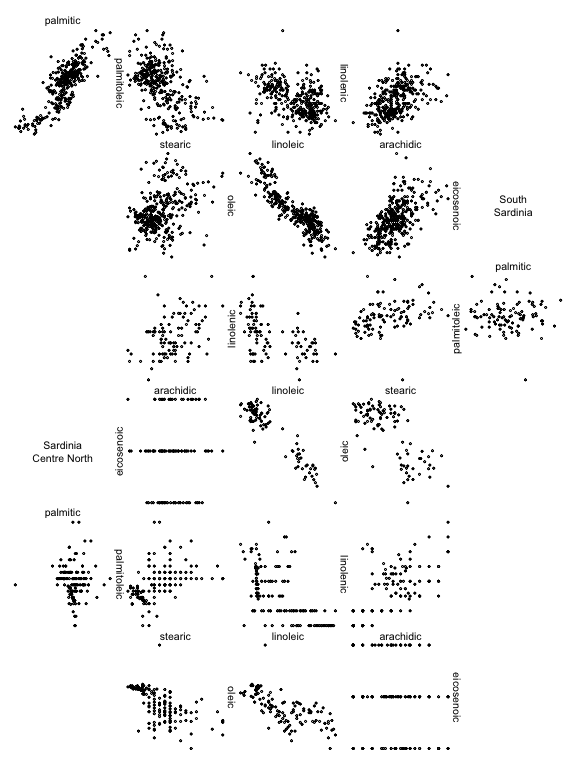

```r
zenplot(oliveAcids.by.area, labs = list(group = NULL))
```

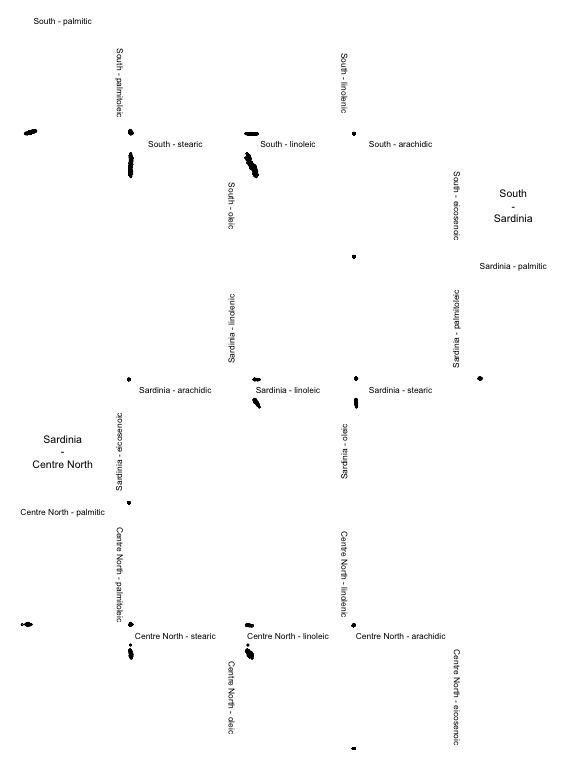

```r
zenplot(oliveAcids.by.area, lim = "groupwise", labs = list(sep = " - "),
        plot1d = function(zargs) label_1d_graphics(zargs, cex = 0.8),
        plot2d = function(zargs)
            points_2d_graphics(zargs, group... = list(sep = "\n - \n")))
```

### 4.5 Custom zenpaths

Find the “convexity” scagnostic for each pair of olive acids.

```r
library(scagnostics)
Y <- scagnostics(oliveAcids) # compute scagnostics (scatter-plot diagonstics)
X <- Y["Convex",] # pick out component 'convex'
d <- ncol(oliveAcids)
M <- matrix(, nrow = d, ncol = d) # matrix with all 'convex' scagnostics
M[upper.tri(M)] <- X # (i,j)th entry = scagnostic of column pair (i,j) of oliveAcids
M[lower.tri(M)] <- t(M)[lower.tri(M)] # symmetrize
round(M, 5)
```

```
##         [,1]    [,2]    [,3]    [,4]    [,5]    [,6]    [,7]    [,8]
## [1,]      NA 0.48952 0.46343 0.45887 0.43914 0.34583 0.31259 0.28413
## [2,] 0.48952      NA 0.42276 0.50499 0.44591 0.35855 0.35846 0.31729
## [3,] 0.46343 0.42276      NA 0.39700 0.36394 0.31316 0.29534 0.33709
## [4,] 0.45887 0.50499 0.39700      NA 0.46454 0.36616 0.29451 0.34888
## [5,] 0.43914 0.44591 0.36394 0.46454      NA 0.31977 0.31443 0.36750
## [6,] 0.34583 0.35855 0.31316 0.36616 0.31977      NA 0.53726 0.34001
## [7,] 0.31259 0.35846 0.29534 0.29451 0.31443 0.53726      NA 0.22231
## [8,] 0.28413 0.31729 0.33709 0.34888 0.36750 0.34001 0.22231      NA
```

Show the six pairs with largest “convexity” scagnostic:

```r
zpath <- zenpath(M, method = "strictly.weighted") # list of ordered pairs
head(M[do.call(rbind, zpath)]) # show the largest six 'convexity' measures
```

```
## [1] 0.5372599 0.5049945 0.4895179 0.4645377 0.4634277 0.4588675
```

Extract the corresponding pairs:

```r
(ezpath <- extract_pairs(zpath, n = c(6, 0))) # extract the first six pairs
```

```
## [[1]]
## [1] 7 6
##
## [[2]]
## [1] 4 2
##
## [[3]]
## [1] 2 1
##
## [[4]]
## [1] 5 4
##
## [[5]]
## [1] 3 1
##
## [[6]]
## [1] 4 1
```

Reproducing Figure 7 (visualizing the pairs):

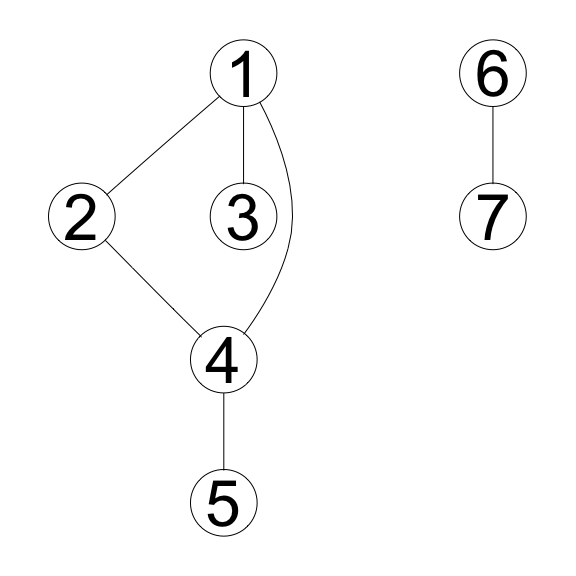

```r
library(graph)
plot(graph_pairs(ezpath)) # depict the six most convex pairs (edge = pair)
```

Connect them:

```r
(cezpath <- connect_pairs(ezpath)) # keep the same order but connect the pairs
```

```
## [[1]]
## [1] 7 6
##
## [[2]]
## [1] 4 2 1
##
## [[3]]
## [1] 5 4
##
## [[4]]
## [1] 3 1 4
```

Build the corresponding list of matrices:

```r
oliveAcids.grouped <- groupData(oliveAcids, indices = cezpath) # group data for (zen)plotting
```

Reproducing Figure 8 (zenplot of the six pairs of acids with largest “convexity” scagnostic):

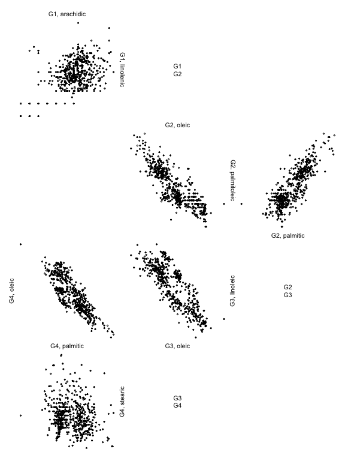

```r
zenplot(oliveAcids.grouped)
```

## 5 Advanced features

### 5.1 The structure of a zenplot

Here is the structure of a return object of `zenplot()`:

```r
res <- zenplot(olive, plot1d = "layout", plot2d = "layout", draw = FALSE)
str(res)
```

```
## List of 2
##  $ path  :List of 3
##   ..$ turns    : chr [1:19] "d" "r" "r" "d" ...
##   ..$ positions: num [1:19, 1:2] 1 2 2 2 3 4 4 4 5 6 ...
##   .. ..- attr(*, "dimnames")=List of 2
##   .. .. ..$ : NULL
##   .. .. ..$ : chr [1:2] "x" "y"
##   ..$ occupancy: chr [1:8, 1:6] "" "" "" "" ...
##  $ layout:List of 6
##   ..$ orientations : chr [1:19] "h" "s" "v" "s" ...
##   ..$ dimensions   : num [1:19] 1 2 1 2 1 2 1 2 1 2 ...
##   ..$ vars         : num [1:19, 1:2] 1 1 2 3 3 3 4 5 5 5 ...
##   .. ..- attr(*, "dimnames")=List of 2
##   .. .. ..$ : NULL
##   .. .. ..$ : chr [1:2] "x" "y"
##   ..$ layoutWidth  : num 33
##   ..$ layoutHeight : num 44
##   ..$ boundingBoxes: num [1:19, 1:4] 0 0 10 11 11 11 21 22 22 22 ...
##   .. ..- attr(*, "dimnames")=List of 2
##   .. .. ..$ : NULL
##   .. .. ..$ : chr [1:4] "left" "right" "bottom" "top"
```

Let’s have a look at the components. The occupancy matrix encodes the occupied cells in the rectangular layout:

```r
res[["path"]][["occupancy"]]
```

```
##      [,1] [,2] [,3] [,4] [,5] [,6]
## [1,] ""   "d"  ""   ""   ""   ""
## [2,] ""   "r"  "r"  "d"  ""   ""
## [3,] ""   ""   ""   "d"  ""   ""
## [4,] ""   ""   ""   "r"  "r"  "d"
## [5,] ""   ""   ""   ""   ""   "d"
## [6,] "l"  "l"  ""   "d"  "l"  "l"
## [7,] ""   "u"  ""   "d"  ""   ""
## [8,] ""   "u"  "l"  "l"  ""   ""
```

The two-column matrix `positions` contains in the *i*th row the row and column index (in the occupancy matrix) of the *i*th plot:

```r
head(res[["path"]][["positions"]])
```

```
##      x y
## [1,] 1 2
## [2,] 2 2
## [3,] 2 3
## [4,] 2 4
## [5,] 3 4
## [6,] 4 4
```

### 5.2 Tools for writing 1d and 2d plot functions

Example structure of 2d plot based on `graphics`:

```r
points_2d_graphics
```

```
## function(zargs,
##                                cex = 0.4, box = FALSE,
##                                add = FALSE, group... = NULL, plot... = NULL, ...)
## {
##     r <- extract_2d(zargs)
##     xlim <- r$xlim
##     ylim <- r$ylim
##     x <- as.matrix(r$x) # for points()
##     y <- as.matrix(r$y)
##     same.group <- r$same.group
##     if(same.group) {
##         if(!add) plot_region(xlim = xlim, ylim = ylim, plot... = plot...) # plot region; uses xlim, ylim
##         points(x = x, y = y, cex = cex, ...)
##         if(box) box(...) # plot the box
##     } else {
##         args <- c(list(zargs = zargs, add = add), group...)
##         do.call(group_2d_graphics, args)
##     }
## }
## <bytecode: 0x10ce897b8>
## <environment: namespace:zenplots>
```

For setting up the plot region of plots based on `graphics`:

```r
plot_region
```

```
## function(xlim, ylim, plot... = NULL)
## {
##     if(is.null(plot...)) {
##         plot(NA, xlim = xlim, ylim = ylim, type = "n", ann = FALSE, axes = FALSE, log = "")
##     } else {
##         fun <- function(...) plot(NA, xlim = xlim, ylim = ylim, ...)
##         do.call(fun, plot...)
##     }
## }
## <bytecode: 0x11001acb8>
## <environment: namespace:zenplots>
```

Determining the indices of the two variables to be plotted in the current 1d or 2d plot (the same for 1d plots):

```r
plot_indices
```

```
## function(zargs)
##     zargs$vars[zargs$num,]
## <bytecode: 0x12ac21d48>
## <environment: namespace:zenplots>
```

Basic check that the return value of `zenplot()` is actually the return value of the underlying `unfold()`:

```r
n2dcols <- ncol(olive) - 1 # number of faces of the hypercube
stopifnot(identical(res, unfold(nfaces = n2dcols)))
```